# Part II - Key Variables Influencing the Turnout of Trips

## by Salima Omari

## Investigation Overview

In this presentation, I would be looking into the variables that have a relationship or influencing the number of trips and duration of trip in the FordGo bike sharing system in San Fransisco. The main focus would be on the month of the year, day of the week, member gender, member usertype, and member age group.

## Dataset Overview

The dataset consist of individual rides made in a bike-sharing system by Ford covering the greater San Francisco Bay area in 2018. It consist of about 1.86 million trips. Trips with user above 80 years old were dropped due to its rare case and insignificant effect to the data.

## Age Distribution of Users

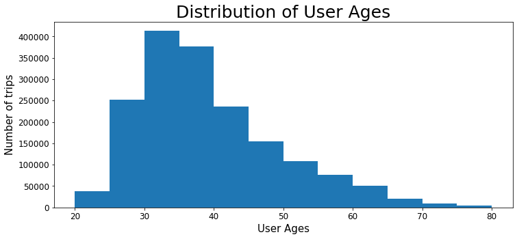

```python
#### How does the Age distribution of users look like ?
binsize = 5
bins = np.arange(20, trip_data['user_age'].max()+binsize, binsize)

CreateHistplot('user_age',bins,'User Ages')
```

## Distribution of Trip Duration

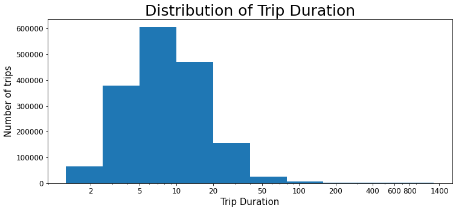

```python
bins = 10 ** np.arange(0.1, 3.2, 0.3)

CreateHistplot('trip_duration(mins)',bins,'Trip Duration')
plt.xscale('log')
plt.xticks([2,5,10,20,50,100,200,400,600,800,1400], [2,5,10,20,50,100,200,400,600,800,1400],fontsize=12)

plt.show()
```

## Frequency distrution of trips in each month and week days of the year

It is observed that more trips happen between From May till October of which October has the most frequent trip, while there is less frequency in trips in the other months with January having the least number of bike trips. Week days also have more trips than weekends.

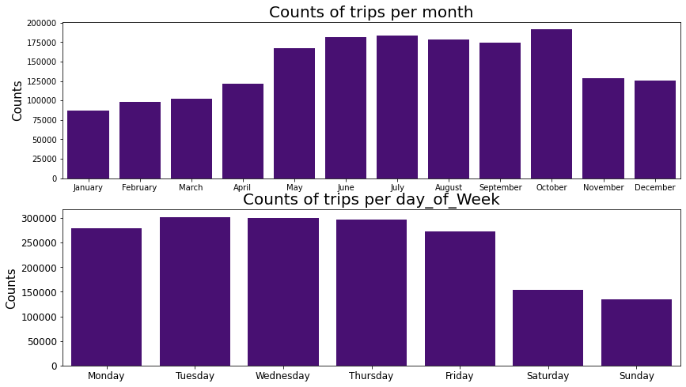

```python
fig, ax = plt.subplots(nrows=2, figsize = [14,8])
for i in range (2):
    CreateCountPlot(trip_data,x[i],'Counts of trips per {}'.format(x[i]), ax = ax[i],order=order[i],hue=None)
    ax[i].set_title('Counts of trips per {}'.format(x[i]), fontsize=20)
    ax[i].set(xlabel=None);
    ax[i].set_ylabel('Counts', fontsize=15)
```

### Percentage distribution of gender and user types.

We have a very large percentage of male users and 89% of the users have subscription membership.

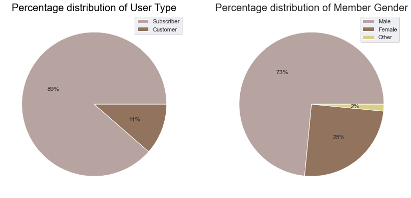

```python
plt.figure(figsize=[14, 8])
plt.subplot(1,2,1)
data=GetPercent('user_type')

# plotting data on chart
CreatePieChart(data[0],data[1],'User Type')
plt.subplot(1,2,2)
data=GetPercent('member_gender')

# plotting data on chart
CreatePieChart(data[0],data[1],'Member Gender')
```

### Months and days with the longest average duration covered in trips

June till September shows the longest average trip duration, which mostly also falls on weekends.

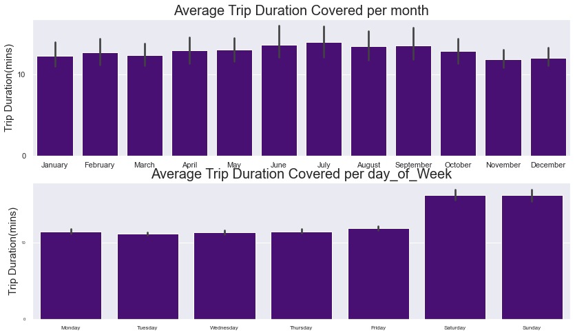

```python
# Create bar subplots
fig, ax = plt.subplots(nrows=2, figsize=[14, 8])
for i in range (2):
    CreateBarPlot(df,'trip_duration(mins)',x[i],'Average Trip Duration Covered per {}'.format(x[i]), ax=ax[i], order=order[i])
    ax[i].set_title('Average Trip Duration Covered per {}'.format(x[i]), fontsize=20)
    ax[i].set(xlabel=None);
    ax[i].set_ylabel('Trip Duration(mins)', fontsize=15)
```

### Average Distribution of Trip Duration Across User Type and Gender

From the above plots, Female users tend to go on longer trips than other genders. Also customer user types go for longer trips. It can also be seen that these customer user type do not partake in bike sharing.

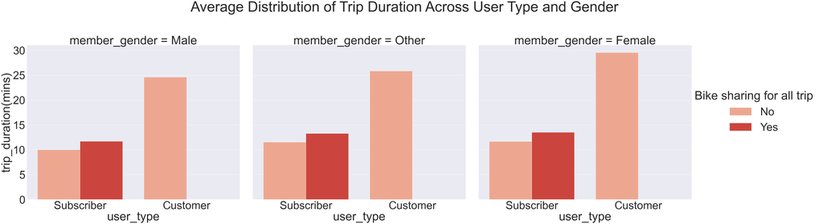

```python
# Create facet grid

CreateFacetGrid(6,20,df,title,'barplot', 'member_gender','user_type','trip_duration(mins)',hue='bike_share_for_all_trip',palette='Reds',legend_title=legend_title)
```

### Trip counts across Hours of the day

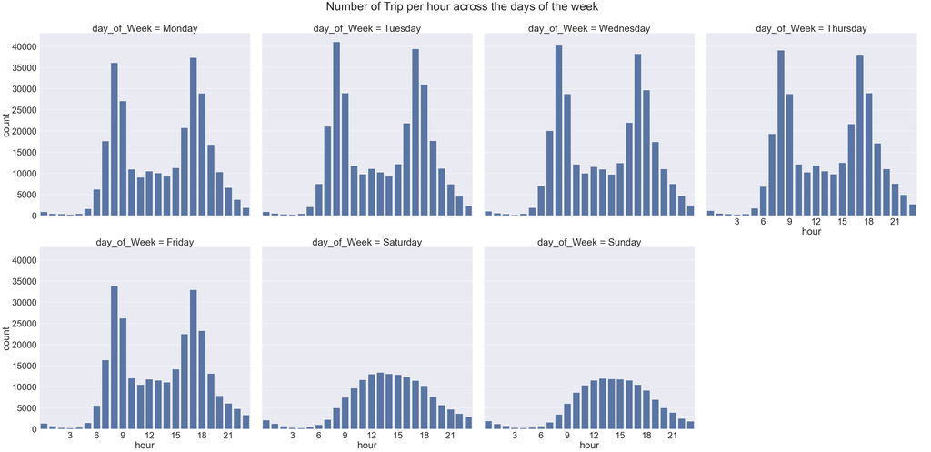

```python
# Create facet grid
g=CreateFacetGrid(3,12,trip_data,title,'countplot', 'day_of_Week','hour','trip_duration(mins)',col_wrap=4,color='blue',col_order=cats)
g.set(xticks=xticks)
```